# Australian MP tweets collection and quick analysis

### Labor

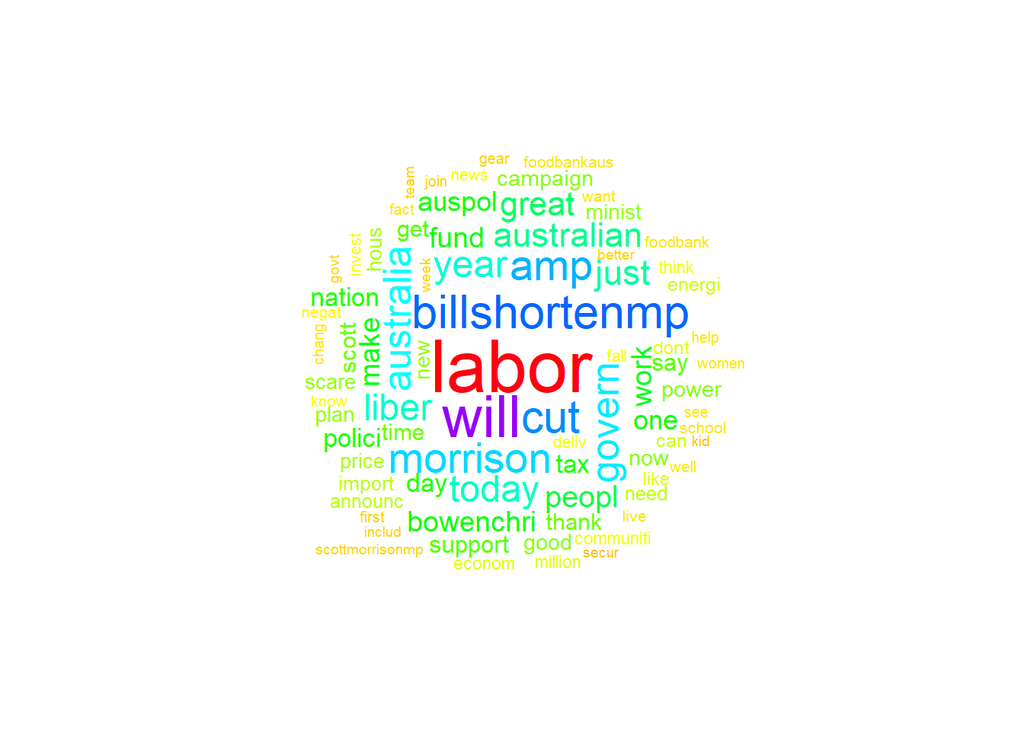

```r
plot.new()
lab_wc <- lab_corp %>% mywordcloud()
```

### Liberals

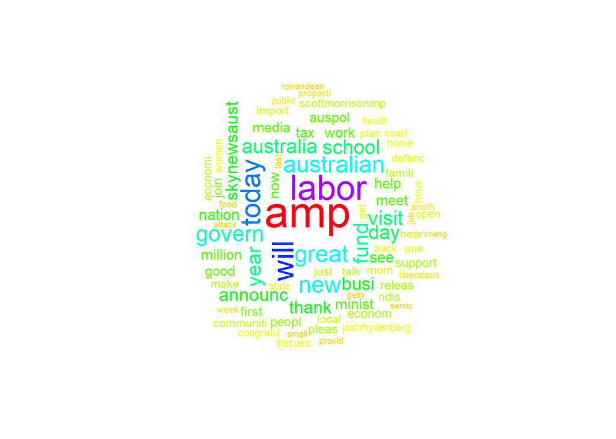

```r
plot.new()
lib_wc <- lib_corp %>% mywordcloud()
```

### Nationals

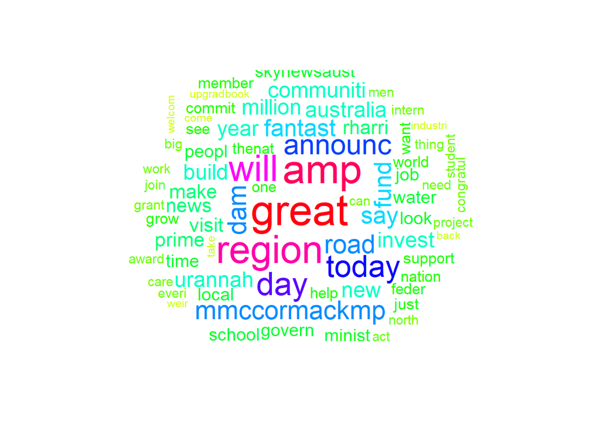

```r
plot.new()
nat_wc <- nat_corp %>% mywordcloud()
```

## Commonality and differences

We can also check what is common in different between content of Twitter posts of different parties.  
First we need wrange the data a bit

```r
## Reducing dimensions - one document per party

# defining function
my_tm <- function (corp, name){
        term.matrix <- termFreq (corp) %>% as.matrix()
        colnames(term.matrix)<- name
        # transpose to merge later
        #term.matrix <- t(term.matrix)
        term.matrix <- as.data.frame(term.matrix)
        term.matrix$word <- row.names(term.matrix)
        return(term.matrix)
}
# to new df
atm_nats <-  my_tm (nat_corp, "Nationals")
atm_libs <-  my_tm (lib_corp, "Liberals")
atm_labs <-  my_tm (lab_corp, "Labor")
# join
atm <- full_join(atm_nats, atm_libs, by = 'word') %>% full_join(atm_labs,by = 'word')
# formatting for further use
row.names(atm)<-atm$word
atm <- atm[c(1,3,4)]
atm <- as.matrix(atm)
atm[is.na(atm)] <- 0
```

Next we can build comparison word cloud and commonality cloud  
### Comparison word cloud

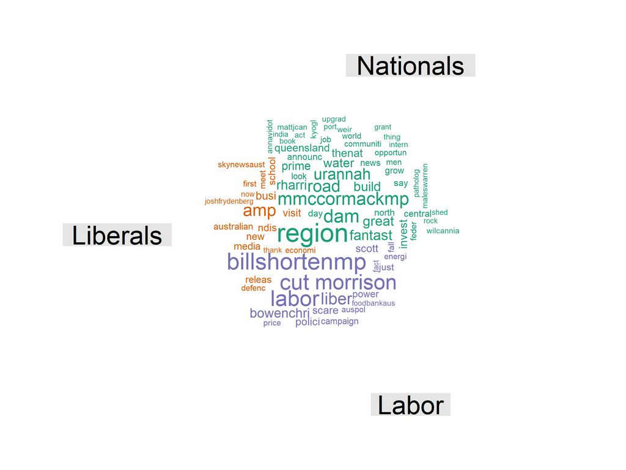

```r
# Comparison Cloud, words that are party specific
plot.new()
comparison.cloud(atm,max.words=80,scale=c(3,.2), random.order=FALSE, colors=brewer.pal(max(3,ncol(atm)),"Dark2"),
                 use.r.layout=FALSE, title.size=3,
                 title.colors=NULL, match.colors=FALSE,
                 title.bg.colors="grey90")
```

### Commonality word cloud

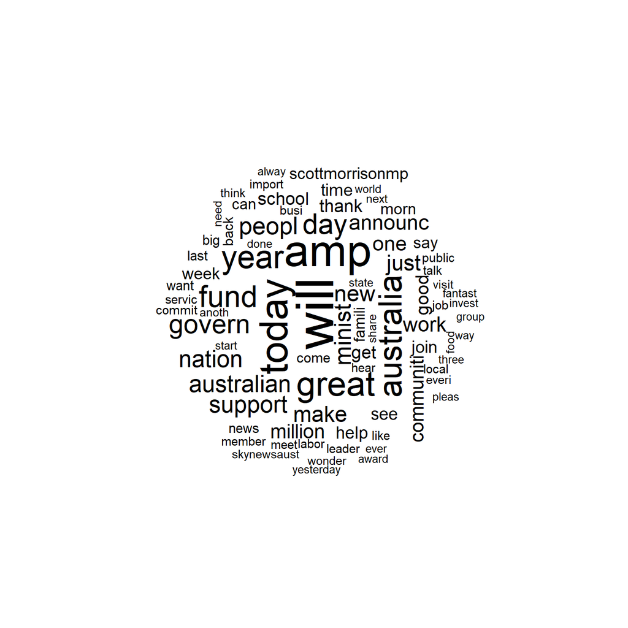

```r
plot.new()
commonality.cloud(atm, max.words=80,random.order=FALSE)
```

## Quick observations

You may do your own analysis of the results, but here are several things that I’ve noticed:

1. All parties use ‘will’ and ‘great’ and ‘Australia’ a lot, probably talking about great things that they will do in the future for our country :)
2. Naturally all MPs often refer party leaders to party leaders (Bill Shorten, Scott Morrison and Michael McCormack). What is interesting that Scott Morison much more often referred by Labor than Bill Shorten by Liberals.
3. Rather than referring party leader, Liberals prefer to talk much more about ‘Labor’ as party.
4. Nationals talk much more about regions - their 9 MPs with Twitter accounts generated over twice as much posts with this keyword as combined ALP (48) and Liberal (37) MPs.
5. Interesting that Labor used word ‘tax’ twice as often as Liberals
6. I was surprised to see so many tweets with ‘amp’ and thought that it is about AMP (financial institution). Appeared that it was formatting used, so i should clean it out.

Full source code and resulting files can be found in Github repository - https://github.com/alevashov/aupolitics/